# Begralveser i Nakskov

Daniel Vistrup Icuspit Sørensen, Annesofie Stilling Lorentzen, Julie Dichmann Christensen

2025-05-19

## Importing the data from a csv

```r
library(tidyverse)
begrav <- read_csv("data/perlestikker - Sheet1.csv",
                                col_types = cols(...9 = col_skip()),
                   na = "NULL")
head(begrav)
```

```
## # A tibble: 6 × 8
##   begrav_index    år måned   dag køn    aldersgruppe sted  navn
##          <dbl> <dbl> <dbl> <dbl> <chr>  <chr>        <chr> <chr>
## 1            1  1619     1     1 kvinde barn         B     ""
## 2            2  1619     1    12 kvinde voksen       C     "Maren"
## 3            3  1619     1    16 kvinde voksen       C     "Maren"
## 4            4  1619     1    27 NA     barn         C     ""
## 5            5  1619     1    28 mand   voksen       C     "Tynnis Guldsmid"
## 6            6  1619     1    31 kvinde voksen       B     "Margrette Kandestøb…
```

## Including a column of dates based on numeric values:

In order to create an accurate plot of the dates of every burial across the two years, I must use the available data to create a new column, where the data is registered as dates in Rstudio.

```r
begrav$dato <- make_date(day = begrav$dag, month = begrav$måned, year = begrav$år)
head(begrav$dato)
```

```
## [1] "1619-01-01" "1619-01-12" "1619-01-16" "1619-01-27" "1619-01-28"
## [6] "1619-01-31"
```

## Making factors for plotting

Another important aspect about the data is its character. For many parts of the data such as gender, age category, and burial location, these values are expressed as character or numeric, which cannot be plotted in Rstudio. Therefore, I change the character of the data into a factor which allows for the data to be put into a data plot. In addition, I use the unique function to analyze the various categories that the data may fall under. For example, the metadata of køn/gender is represented by either “mand”, “kvinde”, or “NA”.

```r
class(begrav$år)
```

```
## [1] "numeric"
```

```r
begrav$år <- factor(begrav$år)
class(begrav$år)
```

```
## [1] "factor"
```

```r
class(begrav$køn)
```

```
## [1] "character"
```

```r
unique(begrav$køn)
```

```
## [1] "kvinde" "NA"     "mand"
```

```r
begrav$køn <- factor(begrav$køn)
class(begrav$køn)
```

```
## [1] "factor"
```

```r
class(begrav$aldersgruppe)
```

```
## [1] "character"
```

```r
unique(begrav$aldersgruppe)
```

```
## [1] "barn"          "voksen"        "voksen + barn" "NA"
```

```r
begrav$aldersgruppe <- factor(begrav$aldersgruppe)
class(begrav$aldersgruppe)
```

```
## [1] "factor"
```

```r
class(begrav$sted)
```

```
## [1] "character"
```

```r
unique(begrav$sted)
```

```
## [1] "B"  "C"  "K"  "NA"
```

```r
begrav$sted <- factor(begrav$sted)
class(begrav$sted)
```

```
## [1] "factor"
```

## Filtering by the year

Another aspect in the analysis of the Perlestikkebogen is the difference between the two years selected for analysis, 1619 and 1620. Therefore, I must filter the data based on the years of 1619 and 1620 and create two new data frames as global environments in Rstudio. In addition, I altered the data in the index column of 1620 by subtracting 132 from every value. This is to ensure that the plotting of burials in the year 1620 start does not start at a high number and instead represent only the total number of burials in 1620.

```r
str(begrav$dato)
```

```
##  Date[1:474], format: "1619-01-01" "1619-01-12" "1619-01-16" "1619-01-27" "1619-01-28" ...
```

```r
bg_1619 <- filter(begrav, format(begrav$dato, "%Y") == "1619")
bg_1620 <- filter(begrav, format(begrav$dato, "%Y") == "1620")
bg_1620$begrav_index <- bg_1620$begrav_index - 132

head(bg_1619)
```

```
## # A tibble: 6 × 9
##   begrav_index år    måned   dag køn    aldersgruppe sted  navn       dato
##          <dbl> <fct> <dbl> <dbl> <fct>  <fct>        <fct> <chr>      <date>
## 1            1 1619      1     1 kvinde barn         B     ""         1619-01-01
## 2            2 1619      1    12 kvinde voksen       C     "Maren"    1619-01-12
## 3            3 1619      1    16 kvinde voksen       C     "Maren"    1619-01-16
## 4            4 1619      1    27 NA     barn         C     ""         1619-01-27
## 5            5 1619      1    28 mand   voksen       C     "Tynnis G… 1619-01-28
## 6            6 1619      1    31 kvinde voksen       B     "Margrett… 1619-01-31
```

```r
head(bg_1620)
```

```
## # A tibble: 6 × 9
##   begrav_index år    måned   dag køn    aldersgruppe sted  navn       dato
##          <dbl> <fct> <dbl> <dbl> <fct>  <fct>        <fct> <chr>      <date>
## 1            1 1620      1     2 mand   voksen       C     "Jørgen K… 1620-01-02
## 2            2 1620      1     2 NA     barn         C     ""         1620-01-02
## 3            3 1620      1     4 NA     barn         C     ""         1620-01-04
## 4            4 1620      1     8 kvinde voksen       C     "Zindell"  1620-01-08
## 5            5 1620      1     9 mand   voksen       C     "Matthis"  1620-01-09
## 6            6 1620      1    10 kvinde voksen       C     "Marren"   1620-01-10
```

## Including Plots

Now, with the data refined and tidied, I can begin the plotting of the data. In the first step, I plot the dates of all burials over 1619, 1620, and both years in a sort of timeline. In addition, I also plotted the number of burials based on each year.

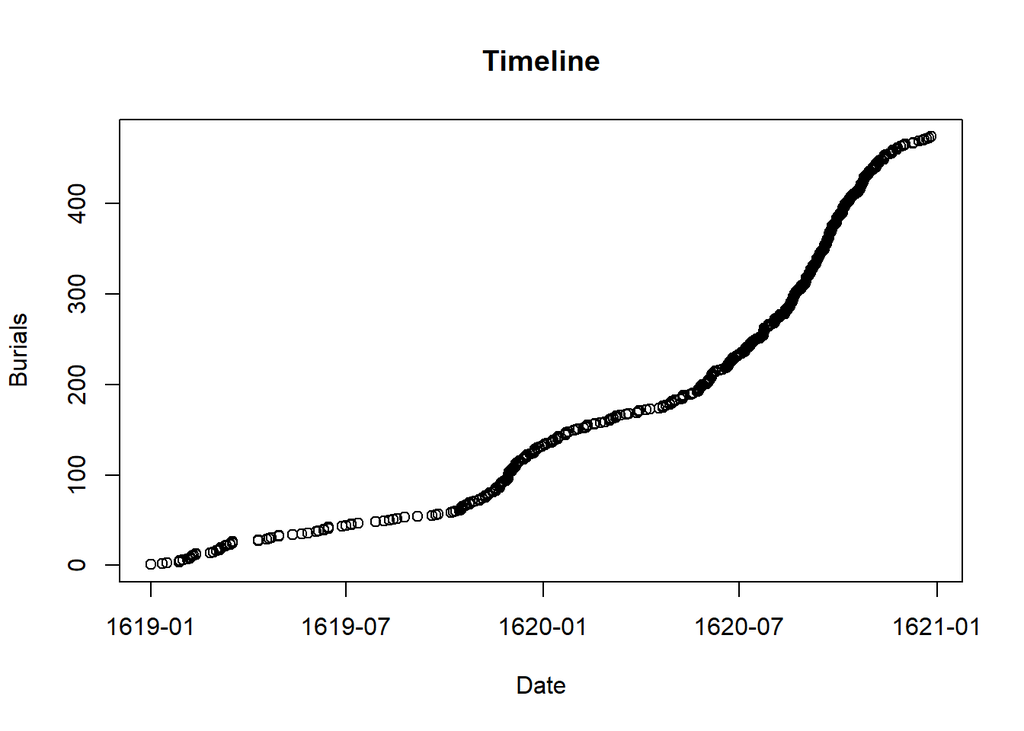

```r
plot(begrav$dato,begrav$begrav_index,
     main = "Timeline",
     xlab = "Date",
     ylab = "Burials")
```

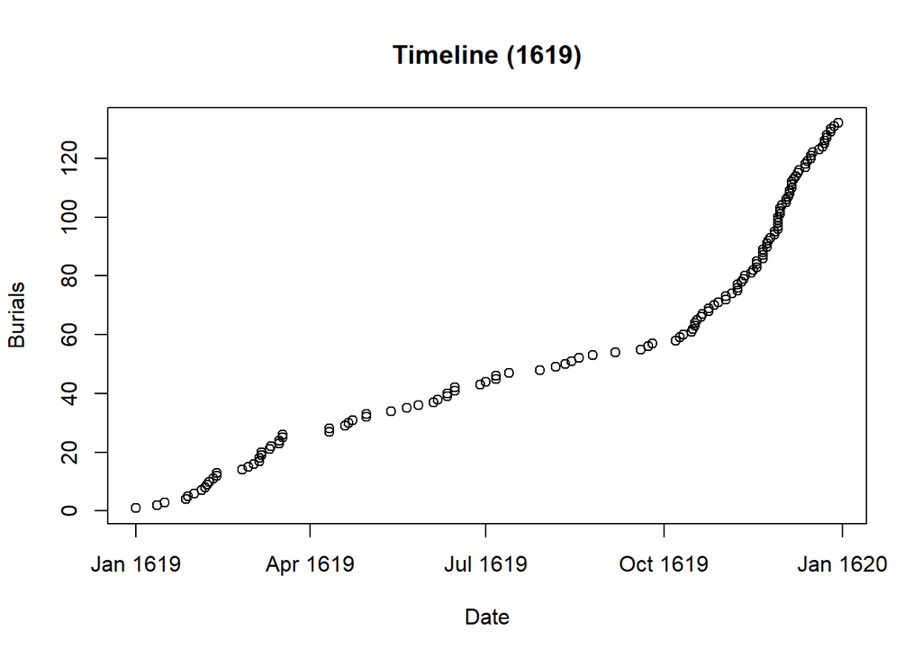

```r
plot(bg_1619$dato,bg_1619$begrav_index,
     main = "Timeline (1619)",
     xlab = "Date",
     ylab = "Burials")
```

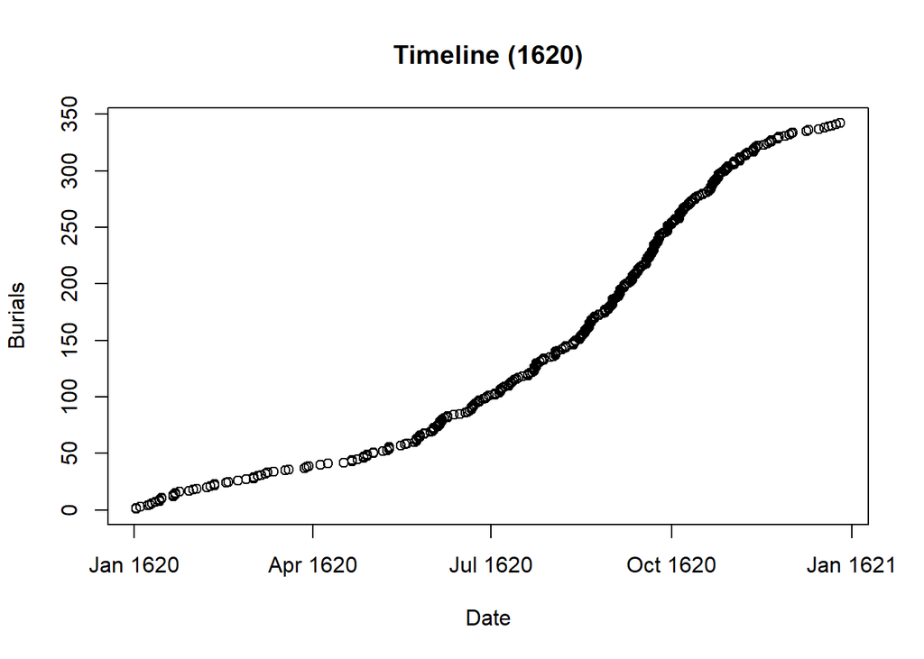

```r
plot(bg_1620$dato, bg_1620$begrav_index,
     main = "Timeline (1620)",
     xlab = "Date",
     ylab = "Burials")
```

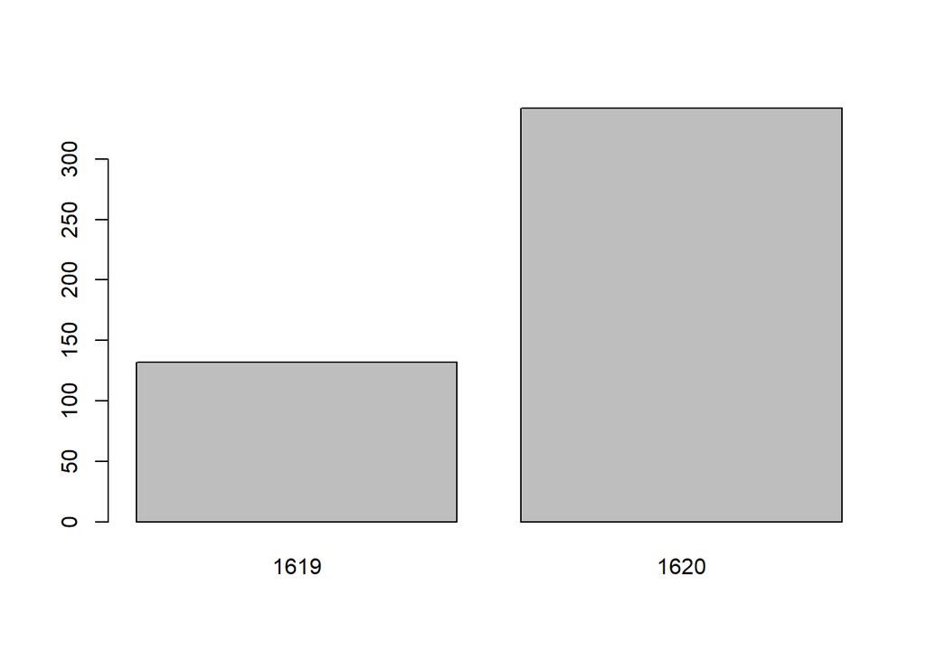

```r
plot(begrav$år)
```

Next, I plot the various aspects of the burials in general, such as gender, age and location.

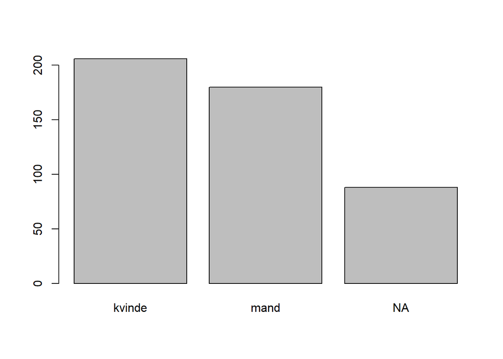

```r
plot(begrav$køn)
```

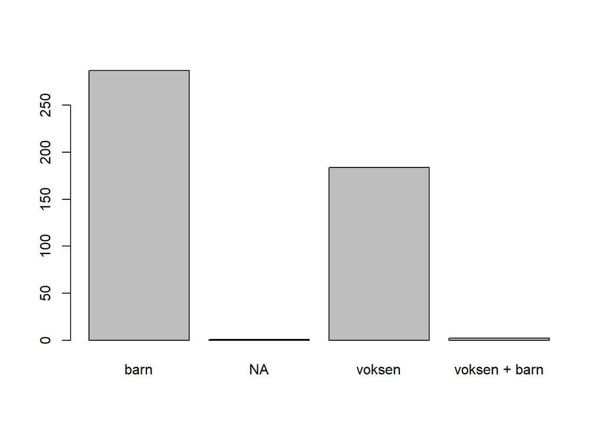

```r
plot(begrav$aldersgruppe)
```

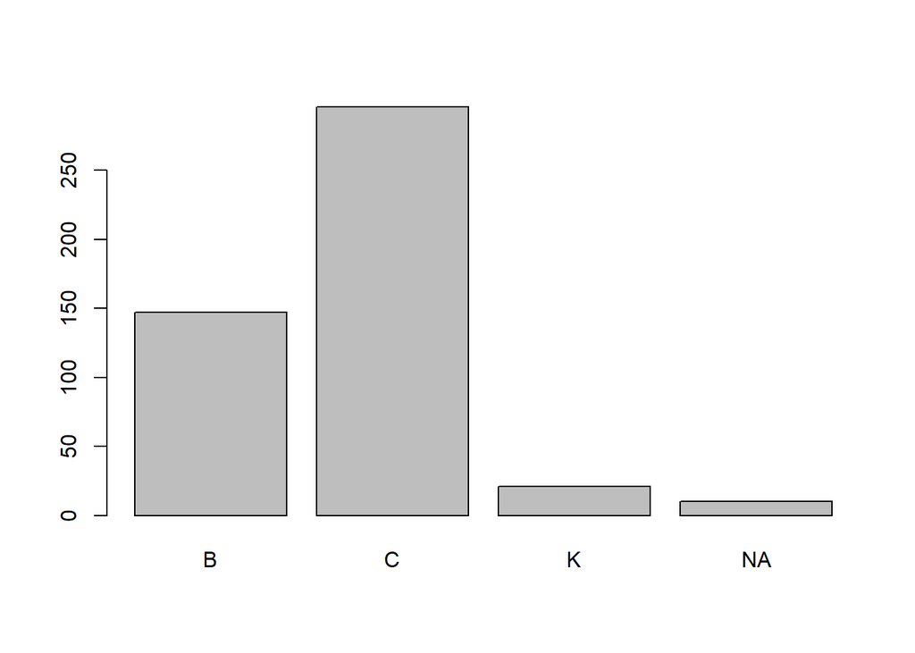

```r
plot(begrav$sted)
```

I repeat this process, but instead focus exclusively on the burials in the year 1619.

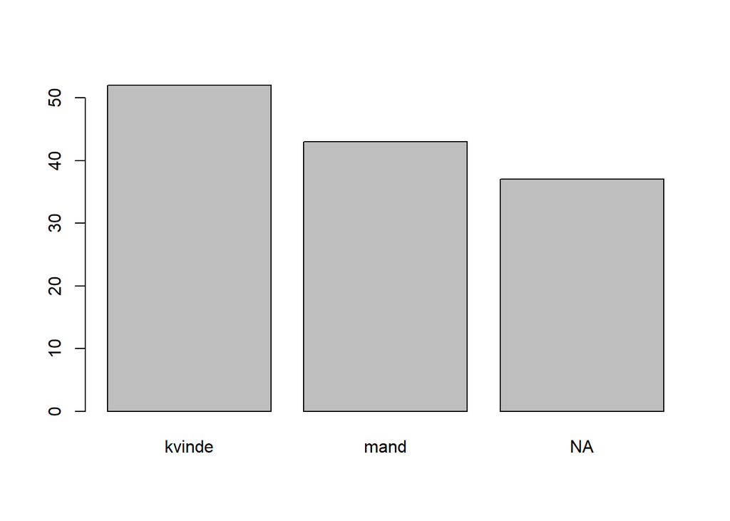

```r
plot(bg_1619$køn)
```

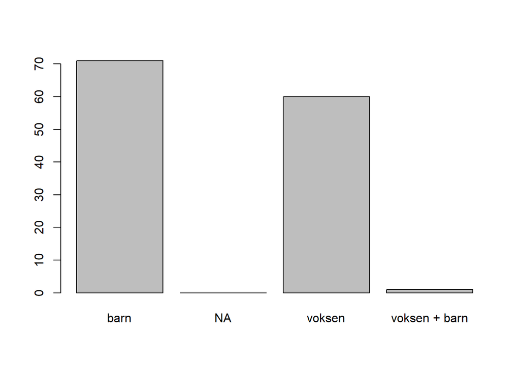

```r
plot(bg_1619$aldersgruppe)
```

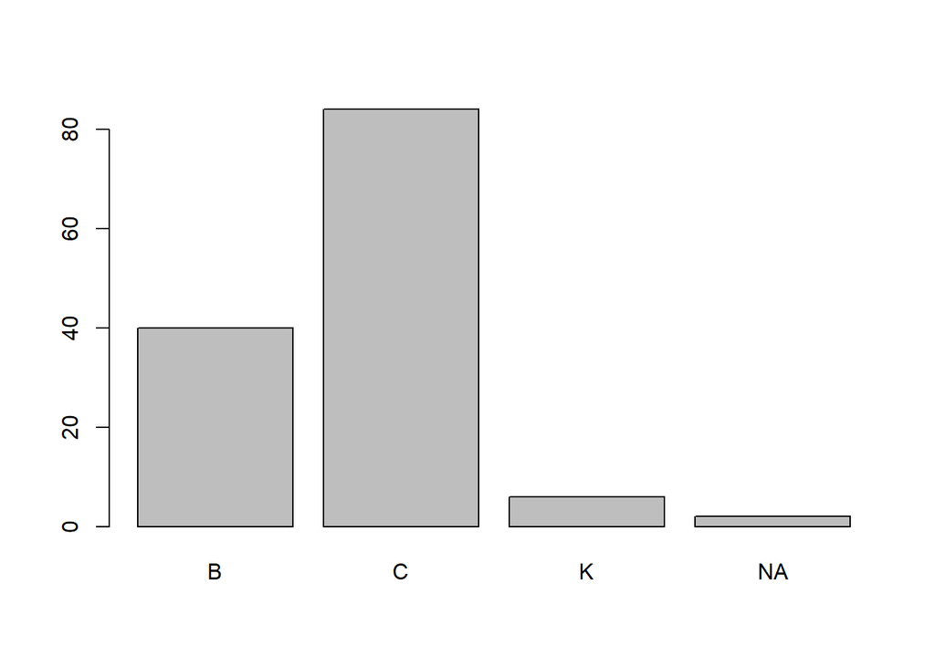

```r
plot(bg_1619$sted)
```

Finally, I analyze the data based on aspects in burials in 1620.

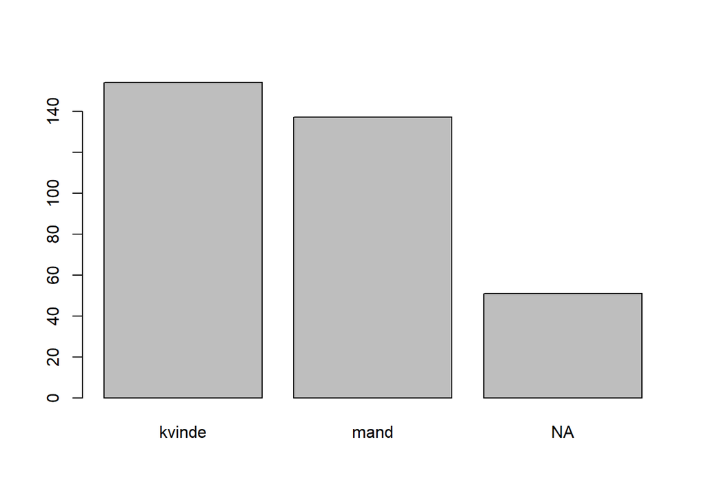

```r
plot(bg_1620$køn)
```

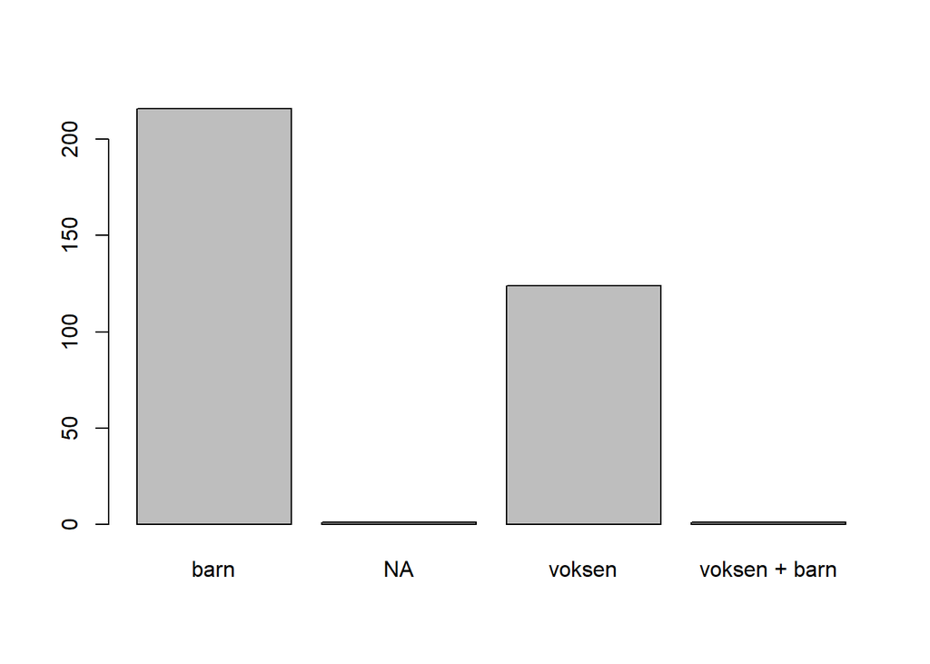

```r
plot(bg_1620$aldersgruppe)
```

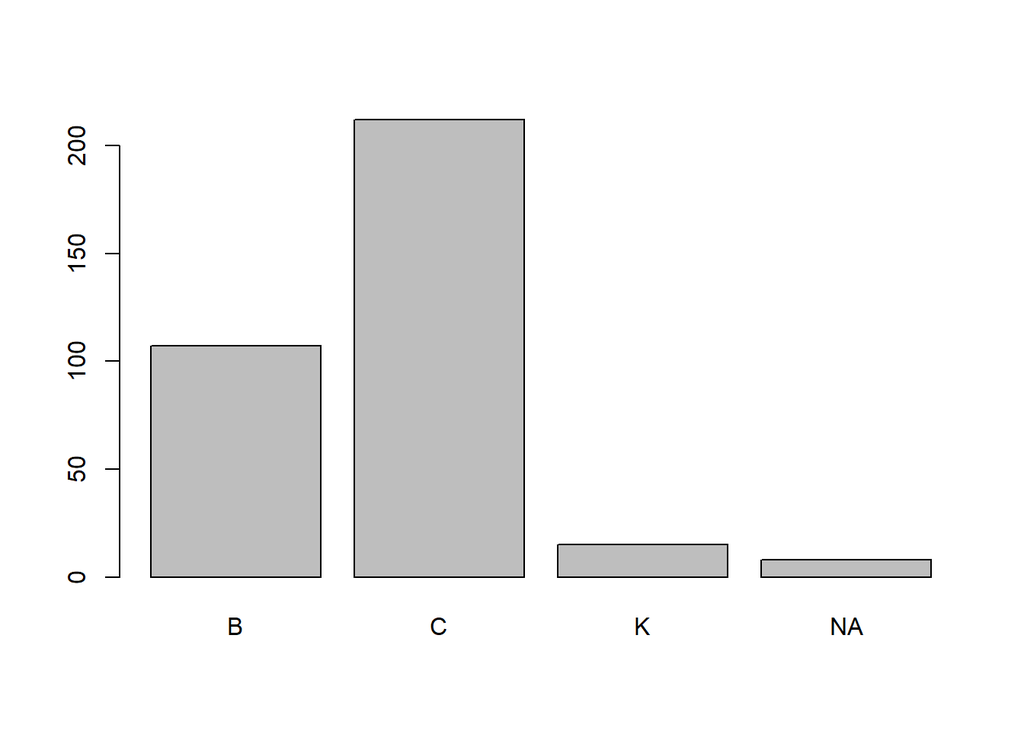

```r
plot(bg_1620$sted)
```